# Jhon Hopkins Prediction Assigment

Suberlin Sinaga

4/3/2021

## Importing & Splitting Data

Importing data is the first thing that we have to do to load the data into our workspace.

```r
df_training <- read.csv("dataset/pml-training.csv") %>% dplyr::select(-1) # select conflict with MASS
df_testing <- read.csv("dataset/pml-testing.csv") %>% dplyr::select(-1) # select conflict with MASS
```

Here we know that our data has training and final testing data set. It means that we have to split the training data in order to have validation data before final prediction.

```r
#for reproducibility
set.seed(123)
index_train <- createDataPartition(y = df_training$classe, p = 0.7, list = FALSE)
df_val <- df_training[-index_train, ]
df_training <- df_training[index_train,]
```

## Preprocessing

In preprocessing process, the first thing I would like to do is to check the missingness.

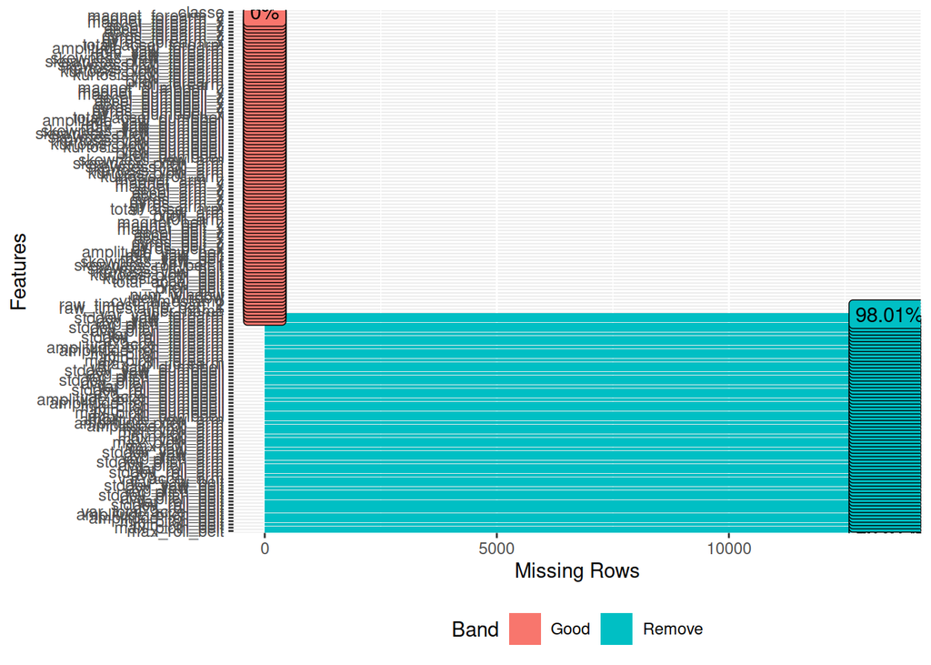

```r
df_training %>%
  plot_missing()
```

As the plot suggest, we need to remove several variables that has NA more than 97%. These variables will not be useful for our analysis. I don’t use knn Impute for the variables since the number of missing is too high.

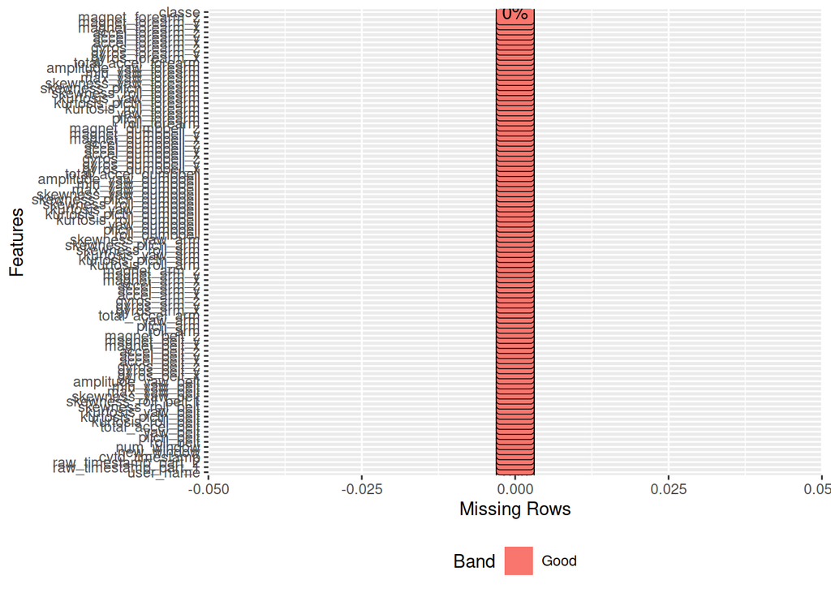

```r
# getting the missing variable
mising <- sapply(df_training, function(a) {sum(is.na(a))/length(a)})
mising <- mising[which(mising > 0.97)] %>% names()
df_training <- df_training[, !names(df_training) %in% mising]

df_training %>%
  plot_missing()
```

Now, we can process next to get near zero variables that might not useful for the model.

```r
nzv <- nearZeroVar(df_training)

df_training <- df_training[, -nzv]
```

After finishing the elimination of the variable in our training set, the next thing we can do is generating final check if the variable satisfies our needs.

```r
str(df_training)
```

```
## 'data.frame':    13737 obs. of  58 variables:
##  $ user_name           : chr  "carlitos" "carlitos" "carlitos" "carlitos" ...
##  $ raw_timestamp_part_1: int  1323084231 1323084231 1323084232 1323084232 1323084232 1323084232 1323084232 1323084232 1323084232 1323084232 ...
##  $ raw_timestamp_part_2: int  788290 808298 196328 368296 484323 484434 528316 560359 576390 644302 ...
##  $ cvtd_timestamp      : chr  "05/12/2011 11:23" "05/12/2011 11:23" "05/12/2011 11:23" "05/12/2011 11:23" ...
##  $ num_window          : int  11 11 12 12 12 12 12 12 12 12 ...
##  $ roll_belt           : num  1.41 1.41 1.48 1.42 1.43 1.45 1.43 1.42 1.42 1.48 ...
##  $ pitch_belt          : num  8.07 8.07 8.07 8.09 8.16 8.17 8.18 8.2 8.21 8.15 ...
##  $ yaw_belt            : num  -94.4 -94.4 -94.4 -94.4 -94.4 -94.4 -94.4 -94.4 -94.4 -94.4 ...
##  $ total_accel_belt    : int  3 3 3 3 3 3 3 3 3 3 ...
##  $ gyros_belt_x        : num  0 0.02 0.02 0.02 0.02 0.03 0.02 0.02 0.02 0 ...
##  $ gyros_belt_y        : num  0 0 0.02 0 0 0 0 0 0 0 ...
##  $ gyros_belt_z        : num  -0.02 -0.02 -0.02 -0.02 -0.02 0 -0.02 0 -0.02 0 ...
##  $ accel_belt_x        : int  -21 -22 -21 -22 -20 -21 -22 -22 -22 -21 ...
##  $ accel_belt_y        : int  4 4 2 3 2 4 2 4 4 4 ...
```

[output cut: 44 more lines]

In this case, i will treat the data not as a time series, so i decide to exclude those variables : `user_name`, `raw_timestamp_part_1`, `raw_timestamp_part_2`, `cvtd_timestamp`. We also see that the classe variable is still in char. We need to change this for both training and validation set.

```r
df_training <- df_training[, !names(df_training) %in% c("user_name", "raw_timestamp_part_1", "raw_timestamp_part_2", "cvtd_timestamp")]

df_training$classe <- as.factor(df_training$classe)
df_val$classe <- as.factor(df_val$classe)
```

Now, we are ready to go.

## Building Model

After choosing the covariates, now I will build the model. In model building. Here I will use random forest using 10 fold cross validation. I also use BoxCox transformation to ensure that there is no too skewed data distribution. To ensure that the algorithms can converge faster I will use scale and center. To ensure that the features are highly optimized, I used pca.

```r
trControl <- trainControl(method = "cv")
model <- train(classe ~ ., data = df_training, method = "rf", preProcess = c("scale", "center", "pca", "BoxCox"),
               trControl = trControl)
```

[output not shown]

```r
model
```

```
## Random Forest
##
## 13737 samples
##    53 predictor
##     5 classes: 'A', 'B', 'C', 'D', 'E'
##
## Pre-processing: scaled (53), centered (53), principal component
##  signal extraction (53), Box-Cox transformation (3)
## Resampling: Cross-Validated (10 fold)
## Summary of sample sizes: 12364, 12364, 12362, 12362, 12364, 12365, ...
## Resampling results across tuning parameters:
##
##   mtry  Accuracy   Kappa
##    2    0.9740116  0.9671266
##   27    0.9648397  0.9555287
##   53    0.9649851  0.9557114
##
## Accuracy was used to select the optimal model using the largest value.
## The final value used for the model was mtry = 2.
```

From the model that we build, we can see that it seems our model is quite good. We have Accuracy greater than 96% with kappa around 96% too.

## Model Testing

The next thing I would like to do is test the model prediction power. To shorten the process, I would like directly test the model for validation test since applying it to the training set will give us the accurace around the model has been printed out.

```r
pred_val <- predict(model, df_val)
confusionMatrix(pred_val, df_val$classe)
```

```
## Confusion Matrix and Statistics
##
##           Reference
## Prediction    A    B    C    D    E
##          A 1658   24    2    0    3
##          B    4 1099   12    2    1
##          C    6   16 1004   46    4
##          D    3    0    6  913    6
##          E    3    0    2    3 1068
##
## Overall Statistics
##
##                Accuracy : 0.9757
##                  95% CI : (0.9714, 0.9795)
##     No Information Rate : 0.2845
##     P-Value [Acc > NIR] : < 2.2e-16
##
##                   Kappa : 0.9693
##
##  Mcnemar's Test P-Value : 2.784e-08
##
## Statistics by Class:
##
##                      Class: A Class: B Class: C Class: D Class: E
## Sensitivity            0.9904   0.9649   0.9786   0.9471   0.9871
## Specificity            0.9931   0.9960   0.9852   0.9970   0.9983
## Pos Pred Value         0.9828   0.9830   0.9331   0.9838   0.9926
## Neg Pred Value         0.9962   0.9916   0.9954   0.9897   0.9971
## Prevalence             0.2845   0.1935   0.1743   0.1638   0.1839
## Detection Rate         0.2817   0.1867   0.1706   0.1551   0.1815
## Detection Prevalence   0.2867   0.1900   0.1828   0.1577   0.1828
## Balanced Accuracy      0.9918   0.9804   0.9819   0.9720   0.9927
```

Magnificent. We can see that here in our validation set, we get quite high prediction accuracy around 98%. I also get positive prediction power around 97.8% and negative prediction power around 99%.